# R Notebook

## Practical Machine Learning project

```r
training = read.csv("D:/Machine Learning/pml-training.csv")
testing  = read.csv("D:/Machine Learning/pml-testing.csv")
str(training)
```

```
'data.frame':   19622 obs. of  160 variables:
 $ X                       : int  1 2 3 4 5 6 7 8 9 10 ...
 $ user_name               : Factor w/ 6 levels "adelmo","carlitos",..: 2 2 2 2 2 2 2 2 2 2 ...
 $ raw_timestamp_part_1    : int  1323084231 1323084231 1323084231 1323084232 1323084232 1323084232 1323084232 1323084232 1323084232 1323084232 ...
 $ raw_timestamp_part_2    : int  788290 808298 820366 120339 196328 304277 368296 440390 484323 484434 ...
 $ cvtd_timestamp          : Factor w/ 20 levels "02/12/2011 13:32",..: 9 9 9 9 9 9 9 9 9 9 ...
 $ new_window              : Factor w/ 2 levels "no","yes": 1 1 1 1 1 1 1 1 1 1 ...
 $ num_window              : int  11 11 11 12 12 12 12 12 12 12 ...
 $ roll_belt               : num  1.41 1.41 1.42 1.48 1.48 1.45 1.42 1.42 1.43 1.45 ...
 $ pitch_belt              : num  8.07 8.07 8.07 8.05 8.07 8.06 8.09 8.13 8.16 8.17 ...
 $ yaw_belt                : num  -94.4 -94.4 -94.4 -94.4 -94.4 -94.4 -94.4 -94.4 -94.4 -94.4 ...
 $ total_accel_belt        : int  3 3 3 3 3 3 3 3 3 3 ...
 $ kurtosis_roll_belt      : Factor w/ 397 levels "","-0.01685",..: 1 1 1 1 1 1 1 1 1 1 ...
 $ kurtosis_picth_belt     : Factor w/ 317 levels "","-0.021887",..: 1 1 1 1 1 1 1 1 1 1 ...
 $ kurtosis_yaw_belt       : Factor w/ 2 levels "","#DIV/0!": 1 1 1 1 1 1 1 1 1 1 ...
```

[output cut: 86 more lines]

```r
table(training$classe)
```

```
   A    B    C    D    E
5580 3797 3422 3216 3607
```

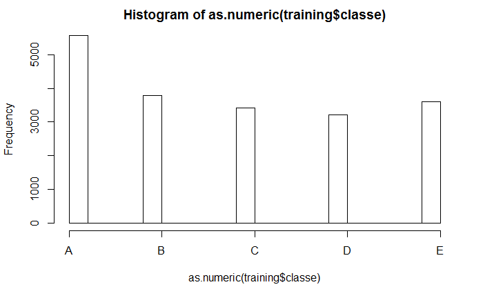

```r
hist(as.numeric(training$classe), xaxt="n")
axis(1, at=seq(1, 5, by=1), labels=c("A", "B", "C", "D", "E"))
```

Most of the observations fall in class A with class B and E having almost the same frequency while class C and D have almost equal lowest frequency.

## Initial feature Selection

The data has columns with missing values and NAs. First we clean the data to get rid of those columns. We start by getting rid of columns with NAs and missing values for both training and test input data.

```r
trainOr<-training[ , colSums(is.na(training)) == 0]
trainOr<-trainOr[ , colSums(trainOr == "") == 0]

testOr<-testing[ , colSums(is.na(testing)) == 0]
testOr<-testOr[ , colSums( testOr== "") == 0]

dim(trainOr);dim(testOr)
str(trainOr)
```

[output not shown]

This leaves us with 60 variables.

## Slitting the original traing data into testing and Validation data

To select the validation data set from the training data we randomise the samples using 75 percent of the data for training and 25 percent for validation( denoted testingVL).

```r
library(caret)
traindf<-createDataPartition(trainOr$classe, p=0.75,list = FALSE)
trainingDt<-trainOr[traindf,]
testingVl<-trainOr[-traindf,]
dim(trainingDt);dim(testingVl)
```

```
[1] 14718    60
[1] 4904   60
```

# Picking features from the training set.

Next we get rid of six variables related to time time and window factor variables as well as all the variables that are highly correlated with other variables (at 0.3 correlation coefficient cutoff).

```r
library(ElemStatLearn)
library("rpart")
library(gbm)
set.seed(33833)
# Reducing factor Variables not needed for training and testing
trainingRD <-trainingDt[-c(1:6)]
testingVlRD<-testingVl[-c(1:6)]
testOrRD <-testOr[-c(1:6)]
#reducing correlating among variables
df_cor = cor(trainingRD[-c(54)])
hc = findCorrelation(df_cor, cutoff=0.3) # putt any value as a "cutoff"
hc = sort(hc)
training_CorRD = trainingRD[,-c(hc)]     # correlation reduced
```

```r
RFmod <- train( classe ~ ., data=training_CorRD, method="rf")
varImp(RFmod)
```

[output not shown]

```r
RFmod
```

```
Random Forest

14718 samples
   13 predictor
    5 classes: 'A', 'B', 'C', 'D', 'E'

No pre-processing
Resampling: Bootstrapped (25 reps)
Summary of sample sizes: 14718, 14718, 14718, 14718, 14718, 14718, ...
Resampling results across tuning parameters:

  mtry  Accuracy   Kappa
   2    0.9898654  0.9871764
   7    0.9961077  0.9950754
  13    0.9930947  0.9912632

Accuracy was used to select the optimal model using the largest value.
The final value used for the model was mtry = 7.
```

# Setting of prediction functions

Here we simplify the model by leaving out variables of low importance for simplicity in order to obtain faster fit and prediction.

```r
RFmod1 <- train(classe ~ num_window +roll_forearm+roll_dumbbell+gyros_belt_z+accel_forearm_z, data=training_CorRD, method="rf")
```

```r
RFmod1
```

```
Random Forest

14718 samples
    5 predictor
    5 classes: 'A', 'B', 'C', 'D', 'E'

No pre-processing
Resampling: Bootstrapped (25 reps)
Summary of sample sizes: 14718, 14718, 14718, 14718, 14718, 14718, ...
Resampling results across tuning parameters:

  mtry  Accuracy   Kappa
  2     0.9937611  0.9921086
  3     0.9962388  0.9952422
  5     0.9945495  0.9931054

Accuracy was used to select the optimal model using the largest value.
The final value used for the model was mtry = 3.
```

Now we can test both the random forest on the validation dataset.

```r
predRFmod1 <- predict(RFmod1, testingVlRD)
```

```r
table(predRFmod1,testingVlRD$classe)
```

```
predRFmod1    A    B    C    D    E
         A 1394    1    0    0    0
         B    1  947    0    0    0
         C    0    0  855    1    0
         D    0    0    0  800    1
         E    0    1    0    3  900
```

```r
confusionMatrix(predRFmod1, testingVlRD$classe)$overall[1]
```

```
 Accuracy
0.9983687
```

As seen above, our model was approx. 99% accurate. To improve on this accuaracy, we develop a boosted trees (“gbm”) model.

[output not shown]

This leads to a comparable Model Simplification

```r
GBMmod1 <- train(classe ~num_window +roll_forearm+gyros_belt_z+roll_dumbbell+accel_forearm_z, data=training_CorRD, method="gbm")
```

```r
GBMmod1
```

```
Stochastic Gradient Boosting

14718 samples
    5 predictor
    5 classes: 'A', 'B', 'C', 'D', 'E'

No pre-processing
Resampling: Bootstrapped (25 reps)
Summary of sample sizes: 14718, 14718, 14718, 14718, 14718, 14718, ...
Resampling results across tuning parameters:

  interaction.depth  n.trees  Accuracy   Kappa
  1                   50      0.5857225  0.4655727
  1                  100      0.6736143  0.5829006
  1                  150      0.7390502  0.6680806
  2                   50      0.8461550  0.8047337
  2                  100      0.9415842  0.9261042
  2                  150      0.9734589  0.9664408
  3                   50      0.9229748  0.9025709
  3                  100      0.9843127  0.9801661
  3                  150      0.9960301  0.9949811

Tuning parameter 'shrinkage' was held constant at a value of 0.1

Tuning parameter 'n.minobsinnode' was held constant at a value of 10
Accuracy was used to select the optimal model using the largest value.
The final values used for the model were n.trees = 150, interaction.depth =
 3, shrinkage = 0.1 and n.minobsinnode = 10.
```

Now we can test simplified boot strapping models on the validation dataset.

```r
predGBMmod1<- predict(GBMmod1, testingVlRD)
```

```r
table(predGBMmod1,testingVlRD$classe)
```

```
predGBMmod1    A    B    C    D    E
          A 1390    1    0    0    0
          B    0  948    0    0    2
          C    0    0  854    3    2
          D    2    0    1  795    0
          E    3    0    0    6  897
```

```r
confusionMatrix(predGBMmod1, testingVlRD$classe)$overall[1]
```

```
 Accuracy
0.9959217
```

The overall accuracy of the boot strapping model is sligthly lower than that of random model. Next we stuck the two model prodictions and developed a hydrid of the two models and test it on the validation data set.

```r
PredStuck <- data.frame(predRFmod1, predGBMmod1, classe=testingVlRD$classe)
Stuckpredmod <- train(classe ~., data=PredStuck, method="rf")
predAllmod <- predict(Stuckpredmod, testingVlRD)
```

```r
Stuckpredmod
```

```
Random Forest

4904 samples
   2 predictor
   5 classes: 'A', 'B', 'C', 'D', 'E'

No pre-processing
Resampling: Bootstrapped (25 reps)
Summary of sample sizes: 4904, 4904, 4904, 4904, 4904, 4904, ...
Resampling results across tuning parameters:

  mtry  Accuracy   Kappa
  2     0.9987779  0.9984555
  5     0.9987325  0.9983976
  8     0.9987774  0.9984545

Accuracy was used to select the optimal model using the largest value.
The final value used for the model was mtry = 2.
```

# Estimation of out of Sampel error from the validation set.

```r
table(predAllmod, testingVlRD$classe)
```

```
predAllmod    A    B    C    D    E
         A 1395    1    0    0    0
         B    0  947    0    0    0
         C    0    0  855    1    0
         D    0    0    0  803    0
         E    0    1    0    0  901
```

```r
confusionMatrix(predAllmod, testingVlRD$classe)$overall[1]
```

```
 Accuracy
0.9993883
```

The model build by combining the two has a much lower error rate than the two independent models.

It seems reasonable to make use of hybrid model for prediction on the test data set, However the random forest “rf” and the boot strapping (“gbm”) models have a satisfactorily low effor rate such that is no siganificant gain in using the hybrid model.

```r
PredTestingOr <- predict(GBMmod1, testOrRD)
```

```r
PredTestingOr1 <- predict(RFmod1, testOrRD)
```

```r
PredTestingOr1==PredTestingOr1;PredTestingOr1
```

```
 [1] TRUE TRUE TRUE TRUE TRUE TRUE TRUE TRUE TRUE TRUE TRUE TRUE
[13] TRUE TRUE TRUE TRUE TRUE TRUE TRUE TRUE
 [1] B A B A A E D B A A B C B A E E A B B B
Levels: A B C D E
```

```r
table(PredTestingOr1)
```

```
PredTestingOr1
A B C D E
7 8 1 1 3
```

```r
table(PredTestingOr)
```

```
PredTestingOr
A B C D E
7 8 1 1 3
```

The frequencies distribution is more skeyed towards classes A and B as it was the case with the training data classes and lowest for classes C and D which turn to have an equal value of unity.

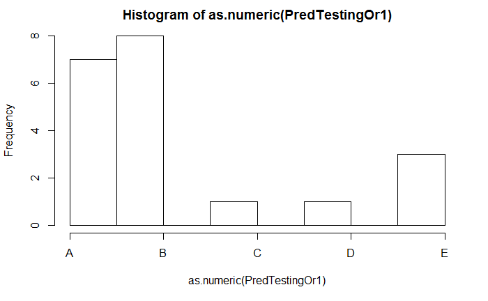

```r
hist(as.numeric(PredTestingOr1), xaxt="n")
axis(1, at=seq(1, 5, by=1), labels=c("A", "B", "C", "D", "E"))
```